# SDS Homework 3

Jonas Barth, Mattia Castaldo, Matteo Migliarini

2023-02-03

# Index

- Simulation Study
  - Parameter Setup
  - Creating Data
  - Friedman Test Function
  - Simulation Loop
  - Different Parameters
- Friedman fMRI Data
  - Feature Engineering
  - fMRI-Friedman

# Simulation Study

In this simulation study, we will examine the Friedman procedure for two sample testing. The goal of the test is to check whether two probability densities are equal, $p(x) = p_0(x)$, by training a **binary classifier** on the dataset containing samples from two classes, and calculating **test statistics** on the scores that the classifier assigns to the samples to calculate a **p-value**. We will use the **permutation** variation, which compares the chosen test statistic calculated on the **original dataset** with the $1 - \alpha$ quantile of a set of $p$ test statistics that were measured on a dataset where the response variables have been permuted. In order to test $H_{0}$ we need to know the null distribution $H_{0}(t)$, but since we are using the same data for training and scoring, the null distribution is not valid, so we permute to make it valid.

For this study, we will use **Logistic Regression** classifier and the **Kolmogorov-Smirnov** test statistic.

## Setting up parameters

We set up the following parameters for the **simulation study**.

- the simulation size $M$.
- the number of dimensions $k$ for each distribution.
- the number of samples from each distribution, $n0$ and $n1$ respectively.
- the confidence level $\alpha$.

```r
M = 1e3

k = 5
n0 = 100
n1 = 150

alpha = 0.05
```

## Creating Data

In this section, we have functions for creating random distributions that will be used in the simulation study. The `random.distro` function let’s us draw **univariate** data from a randomly chosen distribution with a determined *mean* and *standard deviation*. To generate a **k-variate** distribution, we call `random.distro` multiple times in the `random.data` function.

```r
random.distro <- function(n, mean = 1, sd = 1, noisiness = sd * 0.5, eps = 1e-5) {
  #' Generates a univariate random noisy distribution with n samples.
  #'
  #' @param n the number of samples to be generated
  #' @param mean the mean of the population to draw samples from
  #' @param sd the standard deviation of the population to draw samples from
  #' @param noisiness the standard deviation of the gaussian noise to be added
  #' @param eps
  #'
  #' @return a vector of data sampled from a randomly chosen distribution with the provided mean and standard deviation, and with added noise.
  rd <- sample(1:5, 1)[[1]]

  if (rd==1) {
    rate = 1 / sd
    X = rexp(n,rate) + (mean - rate)
  } else if (rd ==2) {
    X = rnorm(n, mean, sd)
  } else if (rd == 3) {
    shape = (mean/sd)^2
    scale = sd / sqrt(shape)
    X = rgamma(n, shape, scale = scale)
  } else if (rd == 4) {
    sd = max(sqrt(2) + eps, sd)
    df = 2 * sd^2 / (sd^2 - 1)
    X = rt(n, df) + mean
  } else {
    b = mean + sd / sqrt(2)
    a = mean - sd / sqrt(2)
    X =  runif(n, a, b)
  }

  noise = rnorm(n, 0, noisiness)
  return(X + noise)
}

random.data <- function(n, k, means = rnorm(k, 0, 3), sds = rnorm(k, 3, 1)) {
  #' Generates a single k-variate random distribution with n samples.
  #'
  #' @param n the number of samples to generate
  #' @param k the number of dimensions the generated data will have
  #' @param means a vector of k mean values, one per dimension
  #' @param sds a vector of standard deviations, one per dimension
  #'
  #' @return a dataframe of random data with n rows and k columns.
  cols = list()
  for (i in 1:k) {
    mean = means[i]
    sd = max(1, sds[i])
    cols[[paste(i)]] = random.distro(n, mean, sd)
  }
  return(data.frame(cols))
}
```

The `create_df` function builds upon the previous functions data generating functions. It generates a dataframe with data drawn from either two separate distributions, or the same distribution. This function is used in the simulation loop and the data returned from it is used to train the **classifier**.

```r
create_df = function(n0, n1, k, H0 = F, shuffle = T, distance = FALSE) {
    #' Creates a dataframe with samples from the two distributions.
    #'
    #' @param n0 number of samples from dist0
    #' @param n1 number of samples from dist1
    #' @param k  number of features
    #' @param H0 if TRUE, all samples will come from the same distribution, if FALSE samples will come from two separate distributions.
    #' @param shuffle if TRUE the data will be randomly shuffled, if FALSE data for the two classes will be grouped in the dataframe.
    #' @param distance if TRUE, the Wasserstein distance between the distributions will be added to the list.
    #'
    #' @return a list with a dataframe with n0 samples from dist0, n1 samples from dist1, and a label column, a train-test split of the data, the means and standard deviations of each of the features.

    means = rnorm(k, 0, 10)
    sds   = rnorm(k, 3, 1)
    if (H0) {
      X  = random.data(n0+n1, k, means, sds)
      X0 = X[1:n0, ]
      X1 = X[(n0+1):(n0+n1), ]
    } else {
      X0 = random.data(n0, k, means, sds)
      X1 = random.data(n1, k, means, sds)
    }

    y0 = rep(0, n0)
    y1 = rep(1, n1)
    y = rep(c(0, 1), c(n0, n1))
    dim(y) = c(n0 + n1, 1)

    n.min = min(n0, n1)
    X0.sample = X0[sample(nrow(X0), n.min), ]
    X1.sample = X1[sample(nrow(X1), n.min), ]

    X = rbind(X0, X1)
    df = data.frame(X)
    df$label = y

    if (shuffle)
      df = df[sample(nrow(df), nrow(df)), ]

    generated = list()
    generated$df = df
    generated$means = means
    generated$sds = sds
    generated$same.src = H0
    generated$X = X
    generated$y = y

    if (distance)
      generated$distance = wasserstein(pp(X0.sample), pp(X1.sample))

    return(generated)
}
```

## Friedman Test Function

We are running the Friedman test with permuting of the labels in the dataset. The `friedman.test.permute.par` function first calculates the **Kolmogorov-Smirnov** statistic on the original data, then permutes the labels $p$ times, calculating the **Kolmogorov-Smirnov** statistic at each permutation. The permutations are done in parallel. Finally, the p-value is calculated by getting the proportion of permuted KS statistics that are greater than or equal to the original statistic.
$$p =
\frac{1}{N} \sum\limits^{N}_{i=1} \mathbb{I}\left(T_i \ge T
\right)$$

```r
friedman.test.permute.par = function(df, alpha = 0.05, p = 1e2, model = "lg") {
  #' Running the Friedman test with permutation
  #' @param df the dataframe to run the Friedman test on. Must have a label column.
  #' @param alpha the alpha value to calculate the test statistic at.
  #' @param p the number of permutations to run
  #' @return a list of the original statistic and the permuted statistic at quantile alpha-
  original.predictions = train.predict(df, model)

  y_pred_class_1 = original.predictions[original.predictions$label == 1, "y_pred"]
  y_pred_class_0 = original.predictions[original.predictions$label == 0, "y_pred"]
  original.statistic = ks.test(y_pred_class_0, y_pred_class_1)$statistic

  test.statistics = produce.test.statistics.par(df, p, model)
  test.statistics = test.statistics$statistics

  p.value = sum(test.statistics >= original.statistic) / length(test.statistics)

  return(list(original=original.statistic, p=p.value, statistics=test.statistics, pred=original.predictions$y_pred))
}
```

## Simulation Loop

The `simulate` function runs $M$ number of simulations to find the **p-value** of the **Kolmogorov-Smirnov** two sample test, using permutation of the response variables. In each simulation, we:

1. Create a **k-variate** dataset, under $H_0$ or $H_1$.
2. Run the Friedman test.
3. Save the **p-value**.

```r
simulate = function(M, n0, n1, k, create.data, H0) {
    #' Simulates operating characteristics of a testing procedure for two distributions.
    #'
    #' @param M the number of simulations
    #' @param n0 the number of samples to draw from the first distribution.
    #' @param n1 the number of samples to draw from the second distribution.
    #' @param k the number of features in each distribution.
    #' @param create.data a function for creating a dataframe containing n0 + n1 samples, from the two distributions. The function should take the parameters n0, n1, k, H0.
    #' @return a result vector with p-values from the testing procedure.

    results = vector(length = M)

    for (i in 1:M) {
        generated = create.data(n0, n1, k, H0 = H0)

        p.value = friedman.test.permute.par(generated$df, alpha = alpha, p = n0 + n1)$p

        results[i] = p.value
    }
    return(results)
}
```

## Results

We can observe that when the null hypothesis is false, i.e. when the data comes from two **separate** distributions, then the distribution of p-values is **highly skewed** towards $0$. In particular we can observe that the p-value is **almost always** under the $\alpha = 0.05$ threshold. This happens because the scores generated by the *Logistic Regression* classifier are distributed in a way which makes it highly likely that they come from **separate** distributions.

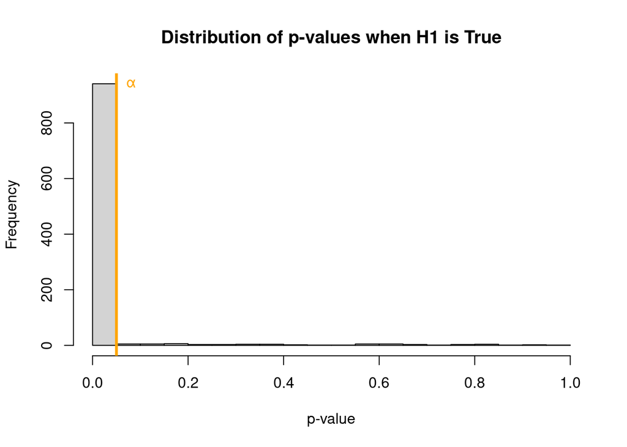

We observe that when the null hypothesis is true, i.e. the data comes from the **same** distribution, the distribution of p-values is almost uniform. This happens because the scores generated by the *Logistic Regression* model are very similar for both classes, which means that the model cannot easily distinguish between them and in turn causes p-values to be uniformly distributed when the scores are given to the **Kolmogorov-Smirnov** test.

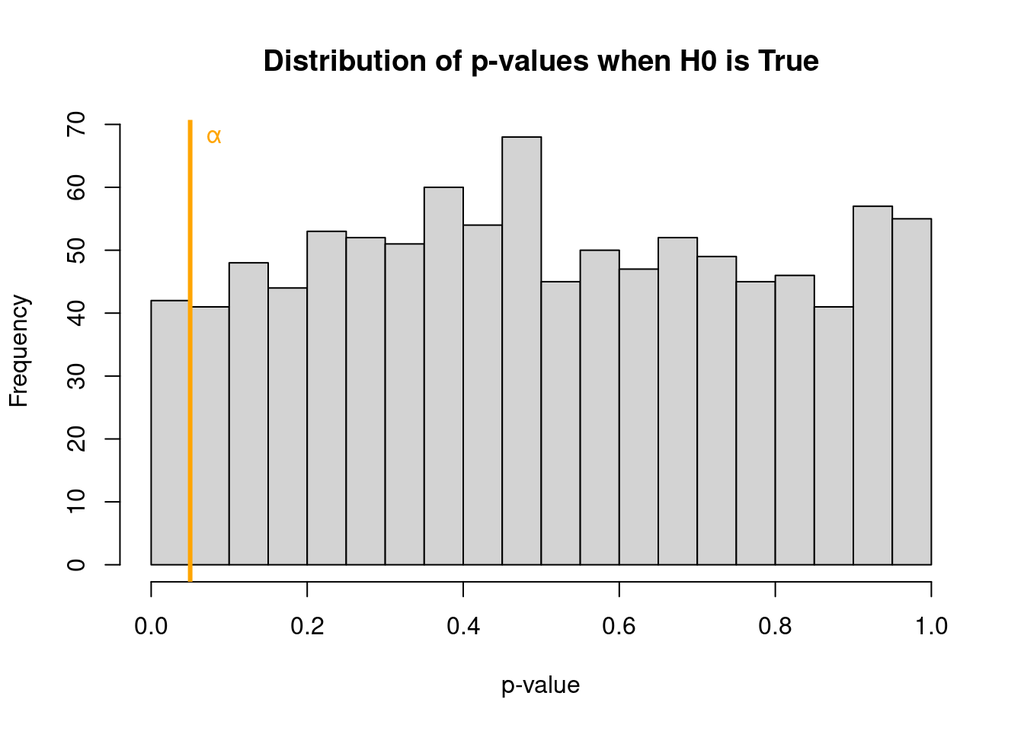

## Experiment with different parameters

Now we’re going to try the same test but with different parameters:

- the number of features per sample: $k \in \{3, 4, 5, 6, 7\}$
- the number of samples in total: $N \in \{250, 1000, 2000\}$

```r
k.values = seq(3, 7)
N.values = c(250, 1000, 2000)
prop.values = c(0.5)

total_params = length(k.values) * length(N.values) * length(prop.values)
params.df = expand.grid(k=k.values, N=N.values, prop=prop.values)

performance = data.frame()

for (i in 1:nrow(params.df)) {
  row = params.df[i, ]
  n0 = as.integer(row$N * row$prop)
  n1 = as.integer(row$N - n0)

  size = foreach(i = 1:M, .combine=c) %dopar% {
    generated = create_df(n0, n1, row$k, H0 = TRUE)

    p.value = friedman.test.permute(generated$df, alpha = alpha, p = n0 + n1)
    p.value
  }
  power = foreach(i = 1:M, .combine=c) %dopar% {
    generated = create_df(n0, n1, row$k, H0 = FALSE)

    p.value = friedman.test.permute(generated$df, alpha = alpha, p = n0 + n1)
    p.value
  }
  performance = rbind(
    data.frame(
      N    = rep.int(row$N, M),
      k    = rep.int(row$k, M),
      size = size,
      power= power
    ),
    performance
  )
}
```

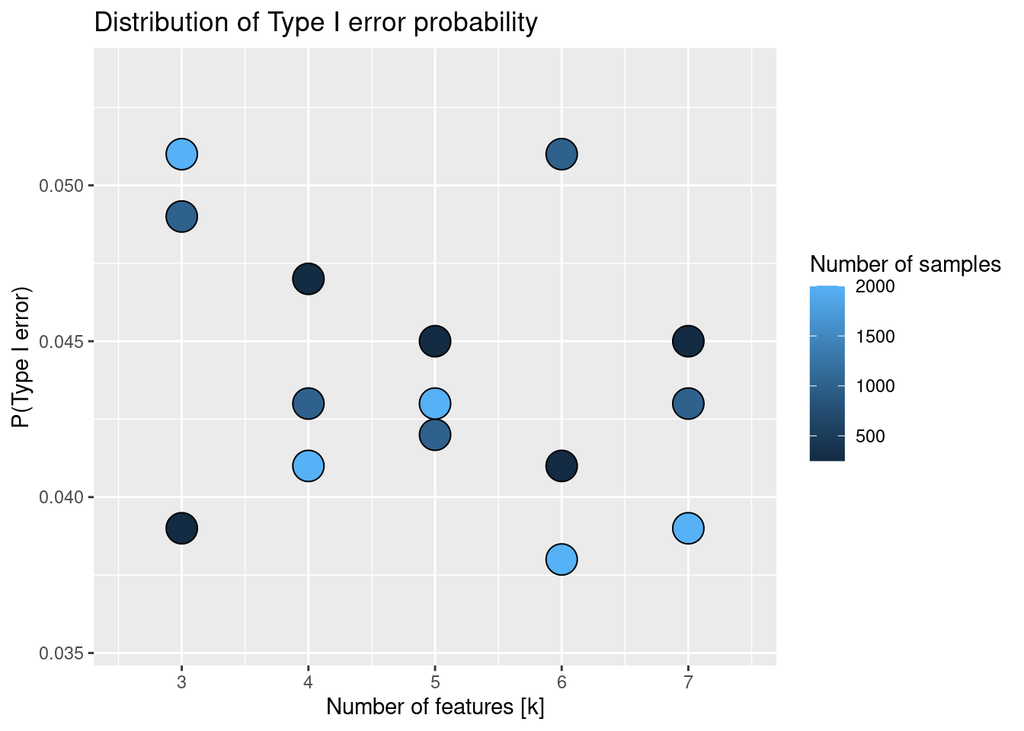

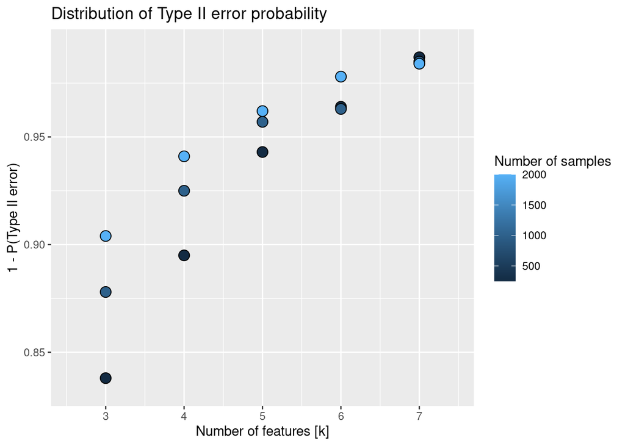

# Friedman fMRI Data

## Feature Engineering

Below are functions for helping us to engineer some features for the **fMRI** dataset. We chose to engineer features across the **time dimension**, such that each brain region is still distinguishable from the others.

```r
#' Applies a certain function to all the time-series columns in a df
apply_per_time <- function(data, func)
  data |>
    lapply(function(patient) sapply(patient, func)) |>
    data.frame() |>
    t() |>
    data.frame()

extract_feat_ts <- function(data, ...)  {
  #' Applies summaries to the data.
  #' @param data a list holding N k-variate time series
  #' @param ...  a number of M functions that take in input an univariate time-series and give in in output a single value
  #'
  #' @return a dataframe of with $N$ rows and $M*k$ columns, one for each function applied to a single time-series
  func.list = list(...)

  func.list |>
    lapply(function(func) apply_per_time(data, func)) %>%
    do.call(cbind.data.frame, . )
  }
```

```r
jump <- function(x, func=mean) {
  #' Applies a function to the difference of each element with the next one
  #' @param x an array of data
  #' @param func the function that should be applied
  L = length(x)

  func(x[2:L] - x[1:(L-1)])
}
```

We chose to extract the following features from the fMRI data for each brain region:

- *mean* over time.
- *median* over time.
- *standard deviation* over time.
- *jump of standard deviations* over time.
- *jumps of means* over time.
- *jumps of medians* over time.

```r
#' Extracts a certain number of feature from the ASD or TD dataset
ts.feature.engine = function(data, label=1) data %>%
  extract_feat_ts(
    mean   = mean,
    median = median,
    sd     = sd,
    jump.sd    = . %>% jump(sd),
    jump.avg   = . %>% jump(mean),
    jump.median= . %>% jump(median)
  ) |>
  cbind(label=label)

asd.ts.feat = ts.feature.engine(asd_data, label=1)
td.ts.feat  = ts.feature.engine(td_data,  label=0)
ts.feat = rbind(asd.ts.feat, td.ts.feat)
ts.feat = ts.feat[-ncol(ts.feat)] %>%
  scale() %>%
  as.data.frame() %>%
  cbind(ts.feat[ncol(ts.feat)])
```

## fMRI Friedman Test

We run the Friedman test on the engineered fMRI data with $p = 1000$ permutations. We are using the Support Vector Machine (SVM) classifier to help combat overfitting.

```r
totalCores = detectCores()

cluster <- makeCluster(totalCores[1]-1)
registerDoParallel(cluster)

fmri.p = friedman.test.permute.par(ts.feat, alpha = 0.05, p = 1e3, model = "svm")

stopCluster(cluster)
```

The histogram below shows the Kolmogorov-Smirnov statistic values for the permuted fMRI response variables. The brown line is at the $1 - \alpha$ percentile of $H0(T)$, where as the green line shows the value of the original statistic before permuting the labels. As we can see, the original statistic is less than the $1 - \alpha$ percentile, which means that we retain the null hypothesis $F_{ASD} = F_{TD}$ with significance level $\alpha$.

However, the learning of the model is dependent on the engineered features on the fMRI dataset. Different features may produce different results.

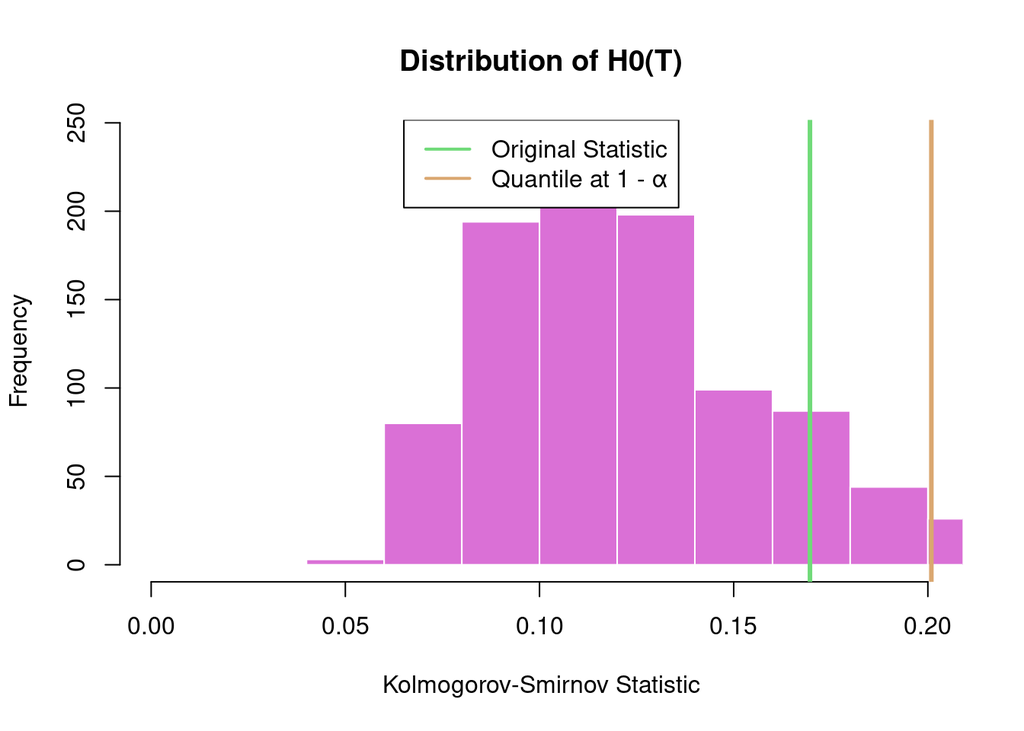

```
## [1] 0.134
```

Below we show the **distribution of scores** predicted by the SVM. The **red part** of the histogram shows the scores assigned to the **ASD samples** by the SVM, the **blue part** the scores assigned to the **TD samples**, and the **purple part** the **intersection** of scores. As we can see, **most** of the histogram is purple, which means that the scores given by the SVM classifier for the two classes were very similar to each other. Visually, this confirms what we saw above. Namely, that the distribution of the **scores** given by the model are so similar in distribution, that we **retain** the null hypothesis.

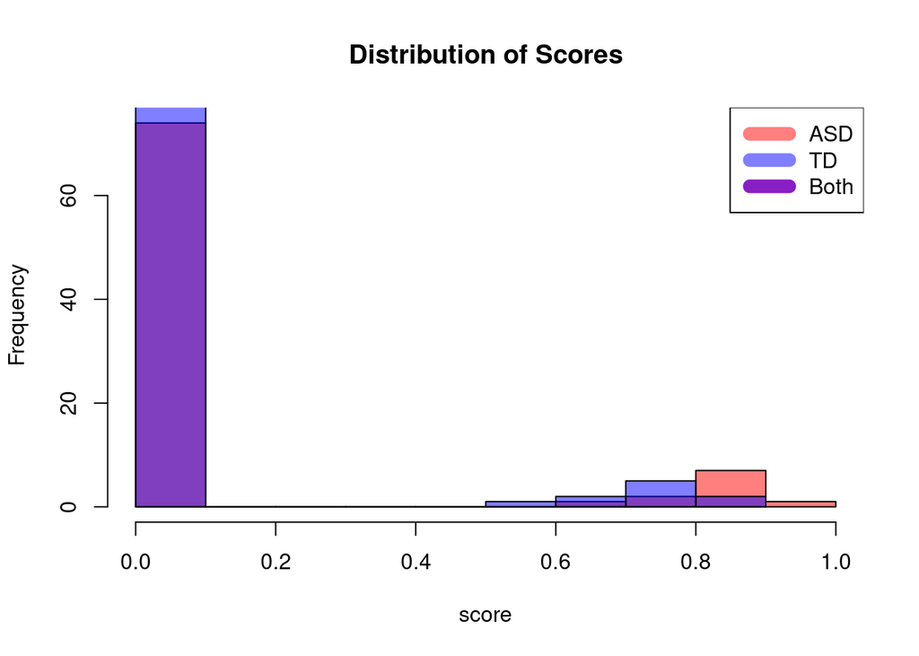